# Accessing the EDGAR 10-K Dataset

- Show All Code
- Hide All Code
- View Source

Research in Corporate Transparency 2026

Author

Fikir Worku Edossa

## 1 Overview

The EDGAR 10-K dataset is available as parquet files on the TRR266 server. The files can be queried directly over HTTPS with DuckDB, so it is not necessary to download the full dataset before starting an analysis.

The dataset contains both filing metadata with downloaded filing documents. Two columns that contain the actual filing text:

- `filing_raw_html`: the raw SEC HTML document.
- `filing_markdown`: a Markdown/plain-text-oriented conversion of the filing.

The full text columns are large. Downloading the text columns for the entire dataset can require around 30 gigabytes of storage. Start with metadata-only queries, then pull text only for the sample needed for a specific research question.

## 2 Setup

The dataset is hosted on the TRR266 server and exposed as a plain HTTPS directory of parquet files — no API, no wildcard expansion. Four steps are needed before queries can run:

1. Import the packages.
2. Scrape the server directory to collect the individual parquet file URLs.
3. Format the URL list into a SQL literal that DuckDB’s `parquet_scan()` accepts.
4. Install the `httpfs` extension, then create a view called `edgar_10k` over the remote files.

The view is a SQL alias, not a local copy of the data. Creating it does not download any filing text — DuckDB pulls only the rows and columns a query actually requests. All of the following queries use `edgar_10k` as their table.

### 2.1 Import Packages

We use DuckDB as the query engine. DuckDB can query parquet files directly and, with the `httpfs` extension, can read remote files over HTTPS. The other packages are used for listing files from the server page, displaying text, and plotting.

```r
suppressPackageStartupMessages({
  library(duckdb)
  library(httr)
  library(rvest)
  library(ggplot2)
  library(htmltools)
})

print_elapsed <- function(start_time, label) {
  elapsed <- (proc.time() - start_time)["elapsed"]
  cat(sprintf("[%s: %.2f s]\n", label, elapsed))
}
```

The base URL points to the TRR266 server directory where the parquet files live. The text column set is used throughout to exclude the large filing columns from metadata-only queries. The sample constants keep the local text sample reproducible and easy to resize.

```r
BASE_URL       <- "https://trr266.wiwi.hu-berlin.de/edgar_10k_apr26/"
TEXT_COLUMNS   <- c("filing_raw_html", "filing_markdown")
SAMPLE_SEED    <- "my-project-seed"
N_TEXT_SAMPLE  <- 100L
```

### 2.2 Collect Remote Parquet Files

The TRR266 server exposes the parquet files through a regular HTTPS directory listing. DuckDB can read the individual files, but it does not expand `*.parquet` automatically for this kind of generic HTTP directory. The helper below reads the directory page and extracts the parquet links.

```r
list_parquet_files <- function(base_url) {
  response <- GET(base_url, timeout(30))
  stop_for_status(response)
  page  <- read_html(content(response, as = "text"))
  links <- html_attr(html_elements(page, "a"), "href")
  links <- links[!is.na(links) & grepl("\\.parquet$", links, ignore.case = TRUE)]
  sort(paste0(base_url, links))
}
```

Now collect the parquet file URLs.

```r
start        <- proc.time()
parquet_urls <- list_parquet_files(BASE_URL)
print_elapsed(start, "list parquet files")
```

```
[list parquet files: 0.14 s]
```

```r
data.frame(n_parquet_files = length(parquet_urls))
```

| n_parquet_files |
| --- |
| 1786 |

### 2.3 Format The File List For DuckDB

`parquet_scan()` can receive a list of files. The next helper turns the R character vector of URLs into a SQL list literal that can be inserted into the DuckDB query.

```r
duckdb_list_literal <- function(urls) {
  escaped <- gsub("'", "''", urls)
  paste0("['", paste(escaped, collapse = "','"), "']")
}

file_list <- duckdb_list_literal(parquet_urls)
```

### 2.4 Set Up DuckDB

`httpfs` is the DuckDB extension that allows remote file access over HTTPS. The metadata cache reduces repeated HTTP metadata requests during the session.

```r
con <- dbConnect(duckdb())
dbExecute(con, "INSTALL httpfs;")
```

```
[1] 0
```

```r
dbExecute(con, "LOAD httpfs;")
```

```
[1] 0
```

```r
dbExecute(con, "SET enable_http_metadata_cache = true;")
```

```
[1] 0
```

### 2.5 Create The EDGAR View

The main object used below is the `edgar_10k` view. The `SELECT` statement also performs a few light type conversions so that mixed source columns such as `sic`, `filmNumber`, and `items` are easier to work with.

```r
dbExecute(con, sprintf("
  CREATE OR REPLACE VIEW edgar_10k AS
  SELECT
    cik,
    name,
    tickers,
    exchanges,
    entityType,
    TRY_CAST(sic AS BIGINT) AS sic,
    sicDescription,
    stateOfIncorporation,
    TRY_CAST(fiscalYearEnd AS BIGINT) AS fiscalYearEnd,
    form,
    filingDate,
    reportDate,
    acceptanceDateTime,
    accessionNumber,
    fileNumber,
    CAST(filmNumber AS VARCHAR) AS filmNumber,
    TRY_CAST(filmNumber AS DOUBLE) AS filmNumber_num,
    CAST(items AS VARCHAR) AS items,
    TRY_CAST(items AS DOUBLE) AS items_num,
    size,
    isXBRL,
    isInlineXBRL,
    primaryDocument,
    primaryDocDescription,
    primaryDocUrl,
    filing_raw_html,
    filing_markdown,
    TRY_CAST(filing_word_count AS BIGINT) AS filing_word_count,
    download_success,
    download_error,
    filename
  FROM parquet_scan(
    %s,
    filename = true,
    union_by_name = true
  )
", file_list))
```

```
[1] 0
```

After this point, queries can refer to `edgar_10k` as if it were a table. DuckDB still keeps the work lazy: selecting metadata columns does not require downloading the full filing text columns.

The first thing to inspect is the schema. This confirms which columns are available before selecting rows.

```r
schema <- dbGetQuery(con, "DESCRIBE edgar_10k")
schema
```

| column_name | column_type | null | key | default | extra |
| --- | --- | --- | --- | --- | --- |
| cik | BIGINT | YES | NA | NA | NA |
| name | VARCHAR | YES | NA | NA | NA |
| tickers | VARCHAR | YES | NA | NA | NA |
| exchanges | VARCHAR | YES | NA | NA | NA |
| entityType | VARCHAR | YES | NA | NA | NA |
| sic | BIGINT | YES | NA | NA | NA |
| sicDescription | VARCHAR | YES | NA | NA | NA |
| stateOfIncorporation | VARCHAR | YES | NA | NA | NA |
| fiscalYearEnd | BIGINT | YES | NA | NA | NA |
| form | VARCHAR | YES | NA | NA | NA |

[output cut: 21 more lines]

The preview blocks below use this small helper to display long filing text with wrapping.

```r
block <- function(text) {
  HTML(paste0(
    '<div class="text-preview-block">',
    htmlEscape(text),
    '</div>'
  ))
}
```

## 3 Dataset Overview

```r
start <- proc.time()
metadata_overview <- dbGetQuery(con, "
  SELECT
    COUNT(*) AS n_rows,
    COUNT(DISTINCT filename) AS n_remote_parquet_files,
    COUNT(DISTINCT cik) AS n_unique_cik,
    COUNT(DISTINCT accessionNumber) AS n_unique_accessions,
    SUM(CASE WHEN download_success THEN 1 ELSE 0 END) AS n_download_success,
    MIN(filingDate) AS first_filing_date,
    MAX(filingDate) AS last_filing_date
  FROM edgar_10k
")
print_elapsed(start, "dataset overview")
```

```
[dataset overview: 5.72 s]
```

```r
metadata_overview
```

| n_rows | n_remote_parquet_files | n_unique_cik | n_unique_accessions | n_download_success | first_filing_date | last_filing_date |
| --- | --- | --- | --- | --- | --- | --- |
| 178519 | 1786 | 33955 | 172109 | 175899 | 1999-06-28 | 2026-04-10 |

## 4 Access Pattern

The practical pattern is to query all columns except the large text columns first. This keeps the first-pass data work fast and manageable.

```r
metadata_columns <- schema$column_name[!schema$column_name %in% TEXT_COLUMNS]
metadata_select  <- paste(sprintf('"%s"', metadata_columns), collapse = ", ")

start <- proc.time()
metadata_preview <- dbGetQuery(con, sprintf("
  SELECT %s
  FROM edgar_10k
  WHERE filingDate IS NOT NULL
  ORDER BY filingDate DESC, cik
  LIMIT 10
", metadata_select))
print_elapsed(start, "metadata preview")
```

```
[metadata preview: 0.29 s]
```

```r
metadata_preview
```

| cik | name | tickers | exchanges | entityType | sic | sicDescription | stateOfIncorporation | fiscalYearEnd | form | filingDate | reportDate | acceptanceDateTime | accessionNumber | fileNumber | filmNumber | filmNumber_num | items | items_num | size | isXBRL | isInlineXBRL | primaryDocument | primaryDocDescription | primaryDocUrl | filing_word_count | download_success | download_error | filename |
| --- | --- | --- | --- | --- | --- | --- | --- | --- | --- | --- | --- | --- | --- | --- | --- | --- | --- | --- | --- | --- | --- | --- | --- | --- | --- | --- | --- | --- |
| 1041859 | Childrens Place, Inc. | PLCE | Nasdaq | operating | 5651 | Retail-Family Clothing Stores | NA | 131 | 10-K | 2026-04-10 | 2026-01-31 | 2026-04-10T20:00:58.000Z | 0001628280-26-024672 | 000-23071 | 26854743.0 | 26854743 | NA | NA | 10809274 | 1 | 1 | plce-20260131.htm | 10-K | https://www.sec.gov/Archives/edgar/data/1041859/000162828026024672/plce-20260131.htm | 58781 | TRUE | NA | https://trr266.wiwi.hu-berlin.de/edgar_10k_apr26/part-00815.parquet |
| 1058623 | CUMULUS MEDIA INC | CMLS\|CMLSQ | OTC\|OTC | operating | 4832 | Radio Broadcasting Stations | DE | 1231 | 10-K | 2026-04-10 | 2025-12-31 | 2026-04-10T12:02:34.000Z | 0001058623-26-000018 | 001-38108 | 26853216.0 | 26853216 | NA | NA | 11358386 | 1 | 1 | cmls-20251231.htm | 10-K | https://www.sec.gov/Archives/edgar/data/1058623/000105862326000018/cmls-20251231.htm | 63324 | TRUE | NA | https://trr266.wiwi.hu-berlin.de/edgar_10k_apr26/part-00771.parquet |
| 1080448 | PATRIOT GOLD CORP | PGOL | OTC | operating | 1040 | Gold and Silver Ores | NV | 1231 | 10-K | 2026-04-10 | 2025-12-31 | 2026-04-10T15:33:26.000Z | 0001683168-26-002795 | 000-32919 | 26853730.0 | 26853730 | NA | NA | 4668220 | 1 | 1 | patriot_i10k-123125.htm | FORM 10-K FOR DEC 2025 | https://www.sec.gov/Archives/edgar/data/1080448/000168316826002795/patriot_i10k-123125.htm | 27450 | TRUE | NA | https://trr266.wiwi.hu-berlin.de/edgar_10k_apr26/part-00727.parquet |
| 1098009 | America Great Health | NA | NA | operating | 2834 | Pharmaceutical Preparations | CA | 630 | 10-K | 2026-04-10 | 2025-06-30 | 2026-04-10T21:25:53.000Z | 0001185185-26-001339 | 000-27873 | 26855810.0 | 26855810 | NA | NA | 6100689 | 1 | 1 | aagh10k063025.htm | FORM 10-K | https://www.sec.gov/Archives/edgar/data/1098009/000118518526001339/aagh10k063025.htm | 20371 | TRUE | NA | https://trr266.wiwi.hu-berlin.de/edgar_10k_apr26/part-00600.parquet |
| 1134982 | Apple iSports Group, Inc. | AAPI | OTC | operating | 6411 | Insurance Agents, Brokers & Service | NV | 1231 | 10-K | 2026-04-10 | 2025-12-31 | 2026-04-10T16:52:35.000Z | 0001477932-26-002110 | 000-32389 | 26853988.0 | 26853988 | NA | NA | 4079915 | 1 | 1 | aapi_10k.htm | FORM 10-K | https://www.sec.gov/Archives/edgar/data/1134982/000147793226002110/aapi_10k.htm | 33772 | TRUE | NA | https://trr266.wiwi.hu-berlin.de/edgar_10k_apr26/part-00638.parquet |
| 1166708 | Brownie's Marine Group, Inc | BWMG | OTC | operating | 3949 | Sporting & Athletic Goods, NEC | FL | 1231 | 10-K | 2026-04-10 | 2025-12-31 | 2026-04-10T21:04:30.000Z | 0001493152-26-016204 | 333-99393 | 26855661.0 | 26855661 | NA | NA | 10221357 | 1 | 1 | form10-k.htm | 10-K | https://www.sec.gov/Archives/edgar/data/1166708/000149315226016204/form10-k.htm | 37457 | TRUE | NA | https://trr266.wiwi.hu-berlin.de/edgar_10k_apr26/part-00927.parquet |
| 1425627 | SOBR Safe, Inc. | SOBR | Nasdaq | operating | 2721 | Periodicals: Publishing or Publishing & Printing | DE | 1231 | 10-K | 2026-04-10 | 2025-12-31 | 2026-04-10T20:20:28.000Z | 0001477932-26-002117 | 001-41396 | 26855150.0 | 26855150 | NA | NA | 6758395 | 1 | 1 | sobr_10k.htm | FORM 10-K | https://www.sec.gov/Archives/edgar/data/1425627/000147793226002117/sobr_10k.htm | 46363 | TRUE | NA | https://trr266.wiwi.hu-berlin.de/edgar_10k_apr26/part-01115.parquet |
| 1494413 | Two Hands Corp | TWOH | OTC | operating | 7389 | Services-Business Services, NEC | NA | 1231 | 10-K | 2026-04-10 | 2025-12-31 | 2026-04-10T19:01:37.000Z | 0001494413-26-000011 | 000-56065 | 26854477.0 | 26854477 | NA | NA | 5206486 | 1 | 1 | twoh12312025k.htm | FORM 10-K | https://www.sec.gov/Archives/edgar/data/1494413/000149441326000011/twoh12312025k.htm | 28216 | TRUE | NA | https://trr266.wiwi.hu-berlin.de/edgar_10k_apr26/part-01028.parquet |
| 1632121 | Balance Labs, Inc. | BLNC | OTC | operating | 8742 | Services-Management Consulting Services | DE | 1231 | 10-K | 2026-04-10 | 2025-12-31 | 2026-04-10T16:39:43.000Z | 0001493152-26-016088 | 333-202959 | 26853949 | 26853949 | NA | NA | 6448486 | 1 | 1 | form10-k.htm | 10-K | https://www.sec.gov/Archives/edgar/data/1632121/000149315226016088/form10-k.htm | 24363 | TRUE | NA | https://trr266.wiwi.hu-berlin.de/edgar_10k_apr26/part-01638.parquet |
| 1662774 | Quince Therapeutics, Inc. | QNCX | Nasdaq | operating | 2836 | Biological Products, (No Diagnostic Substances) | CA | 1231 | 10-K | 2026-04-10 | 2025-12-31 | 2026-04-10T20:35:29.000Z | 0001193125-26-151364 | 001-38890 | 26855392 | 26855392 | NA | NA | 16792188 | 1 | 1 | qncx-20251231.htm | 10-K | https://www.sec.gov/Archives/edgar/data/1662774/000119312526151364/qncx-20251231.htm | 59811 | TRUE | NA | https://trr266.wiwi.hu-berlin.de/edgar_10k_apr26/part-01660.parquet |

## 5 Codebook

| column_name | column_type | text_heavy | description |
| --- | --- | --- | --- |
| cik | BIGINT | FALSE | SEC Central Index Key. Identifies the registrant in EDGAR. |
| name | VARCHAR | FALSE | Registrant name from SEC company metadata. |
| tickers | VARCHAR | FALSE | Ticker symbols reported in SEC company metadata, if available. |
| exchanges | VARCHAR | FALSE | Exchanges associated with the ticker symbols, if available. |
| entityType | VARCHAR | FALSE | SEC entity type, often operating for ordinary registrants. |
| sic | BIGINT | FALSE | Standard Industrial Classification code, cast to numeric when possible. |
| sicDescription | VARCHAR | FALSE | Text label for the SIC industry. |
| stateOfIncorporation | VARCHAR | FALSE | State or jurisdiction of incorporation. |
| fiscalYearEnd | BIGINT | FALSE | Fiscal year-end as MMDD, cast to numeric when possible. |
| form | VARCHAR | FALSE | SEC form type. |

[output cut: 21 more lines]

Rows marked `text_heavy = TRUE` are the columns to avoid in first-pass full-dataset queries.

## 6 Industry Coverage

```r
start <- proc.time()
top_sic <- dbGetQuery(con, "
  SELECT sic, sicDescription, COUNT(*) AS n
  FROM edgar_10k
  WHERE sicDescription IS NOT NULL
  GROUP BY sic, sicDescription
  ORDER BY n DESC
  LIMIT 10
")
print_elapsed(start, "industry coverage")
```

```
[industry coverage: 0.18 s]
```

```r
top_sic
```

| sic | sicDescription | n |
| --- | --- | --- |
| 6189 | Asset-Backed Securities | 21930 |
| 2834 | Pharmaceutical Preparations | 9214 |
| 6798 | Real Estate Investment Trusts | 6320 |
| 7372 | Services-Prepackaged Software | 5479 |
| 6022 | State Commercial Banks | 5358 |
| 1311 | Crude Petroleum & Natural Gas | 4474 |
| 6770 | Blank Checks | 3656 |
| 7389 | Services-Business Services, NEC | 3502 |
| 6021 | National Commercial Banks | 2854 |
| 3841 | Surgical & Medical Instruments & Apparatus | 2763 |

## 7 Example: Filing Length Over Time

`filing_word_count` is a transparent first variable for studying disclosure length or complexity.

```r
start <- proc.time()
filings_by_year <- dbGetQuery(con, "
  SELECT
    SUBSTR(filingDate, 1, 4) AS filing_year,
    COUNT(*) AS n_filings,
    COUNT(DISTINCT cik) AS n_unique_cik,
    CAST(ROUND(MEDIAN(filing_word_count)) AS BIGINT) AS median_words,
    CAST(ROUND(AVG(filing_word_count)) AS BIGINT) AS mean_words
  FROM edgar_10k
  WHERE filingDate IS NOT NULL
    AND filing_word_count IS NOT NULL
  GROUP BY filing_year
  ORDER BY filing_year
")
print_elapsed(start, "filings by year")
```

```
[filings by year: 0.23 s]
```

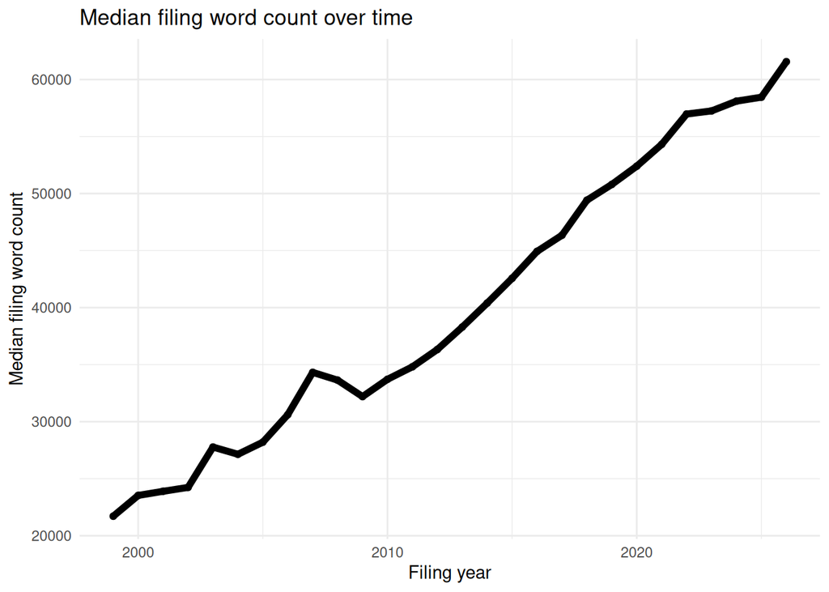

```r
filings_by_year$filing_year <- as.integer(filings_by_year$filing_year)

ggplot(filings_by_year, aes(x = filing_year, y = median_words)) +
  geom_line(linewidth = 2) +
  geom_point() +
  labs(
    x     = "Filing year",
    y     = "Median filing word count",
    title = "Median filing word count over time"
  ) +
  theme_minimal()
```

## 8 Annual Summary

```r
filings_by_year
```

| filing_year | n_filings | n_unique_cik | median_words | mean_words |
| --- | --- | --- | --- | --- |
| 1999 | 16 | 16 | 21713 | 22200 |
| 2000 | 519 | 516 | 23534 | 24526 |
| 2001 | 3132 | 3095 | 23897 | 24597 |
| 2002 | 5267 | 5133 | 24238 | 24606 |
| 2003 | 6445 | 6367 | 27774 | 28623 |
| 2004 | 6596 | 6506 | 27141 | 27881 |
| 2005 | 7080 | 7015 | 28203 | 28777 |
| 2006 | 6940 | 6880 | 30613 | 30927 |
| 2007 | 6687 | 6557 | 34324 | 36146 |
| 2008 | 6917 | 6779 | 33641 | 34243 |

[output cut: 18 more lines]

## 9 Saving A Text Sample Locally

For text analysis, save a sample rather than the full corpus. The full text columns can reach tens of gigabytes across the whole dataset. The workflow below first stores the selected observation identifiers, `cik` and `accessionNumber`, in a temporary table. It also keeps `filename` internally so DuckDB can fetch text from only the parquet files that contain the selected observations.

```r
text_sample_path <- "edgar_10k_markdown_sample.parquet"
if (file.exists(text_sample_path)) file.remove(text_sample_path)
```

```
[1] TRUE
```

```r
start <- proc.time()
dbExecute(con, sprintf("
  CREATE OR REPLACE TEMP TABLE text_sample_ids AS
  SELECT cik, accessionNumber, filename
  FROM (
    SELECT DISTINCT cik, accessionNumber, filename
    FROM edgar_10k
    WHERE download_success = true
      AND filing_word_count IS NOT NULL
      AND cik IS NOT NULL
      AND accessionNumber IS NOT NULL
      AND filename IS NOT NULL
  ) AS eligible_filings
  ORDER BY hash(CAST(cik AS VARCHAR) || accessionNumber || '%s')
  LIMIT %d
", SAMPLE_SEED, N_TEXT_SAMPLE))
```

```
[1] 100
```

```r
selected_text_files <- dbGetQuery(con, "
  SELECT DISTINCT filename
  FROM text_sample_ids
  ORDER BY filename
")$filename
selected_text_file_list <- duckdb_list_literal(selected_text_files)

dbExecute(con, sprintf("
  COPY (
    SELECT
      TRY_CAST(e.cik AS BIGINT) AS cik,
      e.name,
      e.sicDescription,
      e.form,
      e.filingDate,
      e.reportDate,
      e.accessionNumber,
      e.primaryDocUrl,
      TRY_CAST(e.filing_word_count AS BIGINT) AS filing_word_count,
      e.filing_markdown,
      e.filing_raw_html
    FROM parquet_scan(
      %s,
      filename = true,
      union_by_name = true
    ) AS e
    INNER JOIN text_sample_ids AS s
      ON TRY_CAST(e.cik AS BIGINT) = s.cik
     AND e.accessionNumber = s.accessionNumber
     AND e.filename = s.filename
    ORDER BY hash(CAST(TRY_CAST(e.cik AS BIGINT) AS VARCHAR) || e.accessionNumber || '%s')
  )
  TO '%s'
  (FORMAT PARQUET)
", selected_text_file_list, SAMPLE_SEED, text_sample_path))
```

```
[1] 100
```

```r
print_elapsed(start, "save text sample")
```

```
[save text sample: 61.12 s]
```

After saving, check the size and shape.

```r
start <- proc.time()
text_sample_shape <- dbGetQuery(con, sprintf("
  SELECT
    COUNT(*) AS n_observations,
    COUNT(*) FILTER (WHERE filing_markdown IS NOT NULL) AS n_with_markdown,
    COUNT(*) FILTER (WHERE filing_raw_html IS NOT NULL) AS n_with_html
  FROM read_parquet('%s')
", text_sample_path))
print_elapsed(start, "text sample summary")
```

```
[text sample summary: 0.14 s]
```

```r
text_sample_columns <- dbGetQuery(con, sprintf(
  "DESCRIBE SELECT * FROM read_parquet('%s')", text_sample_path
))

cbind(
  text_sample_shape,
  n_columns    = nrow(text_sample_columns),
  file_size_mb = round(file.info(text_sample_path)$size / 1024^2, 2)
)
```

| n_observations | n_with_markdown | n_with_html | n_columns | file_size_mb |
| --- | --- | --- | --- | --- |
| 100 | 100 | 100 | 11 | 42.76 |

## 10 Inspecting Filing Text

One filing from the saved sample is displayed below. Both text columns were saved locally, so no additional remote fetching is needed.

```r
start <- proc.time()
text_preview <- dbGetQuery(con, sprintf("
  SELECT
    cik,
    name,
    form,
    filingDate,
    sicDescription,
    filing_word_count,
    primaryDocUrl,
    filing_markdown AS markdown_preview,
    filing_raw_html AS html_preview
  FROM read_parquet('%s')
  WHERE filing_markdown IS NOT NULL
    AND filing_raw_html IS NOT NULL
  ORDER BY hash(COALESCE(accessionNumber, '') || 'rct2026-preview')
  LIMIT 1
", text_sample_path))
print_elapsed(start, "text preview")
```

```
[text preview: 0.28 s]
```

```r
text_preview[, c("cik", "name", "form", "filingDate", "sicDescription",
                 "filing_word_count", "primaryDocUrl")]
```

| cik | name | form | filingDate | sicDescription | filing_word_count | primaryDocUrl |
| --- | --- | --- | --- | --- | --- | --- |
| 1270430 | PDC 2003-D LP | 10-K | 2005-04-25 | Drilling Oil & Gas Wells | 9949 | https://www.sec.gov/Archives/edgar/data/1270430/000127043005000002/pdc10k03d041.htm |

## 11 Markdown Preview

```r
block(text_preview$markdown_preview[1])
```